# Reproducible Research: Peer Assessment 1

## Loading and preprocessing the data

Set the working directory and read in the data:

```r
setwd("~/Documents/Coursera - Data Science Specialization/Part 5 - Reproducible Research/RepData_PeerAssessment1")
activity <- read.csv("activity.csv")
```

Load dplyr and ggplot2 packages:

```r
library("dplyr", lib.loc="/Library/Frameworks/R.framework/Versions/3.0/Resources/library")
```

```r
library("ggplot2", lib.loc="/Library/Frameworks/R.framework/Versions/3.0/Resources/library")
```

## What is mean total number of steps taken per day?

Use dplyr to find total number of steps taken per day:

```r
daily <- group_by(activity,date)
daily2 <- summarise(daily, dailysteps = sum(steps, na.rm=T))
daily2$dailysteps <- as.numeric(as.character(daily2$dailysteps))
```

Histogram plot of total number of steps taken each day:

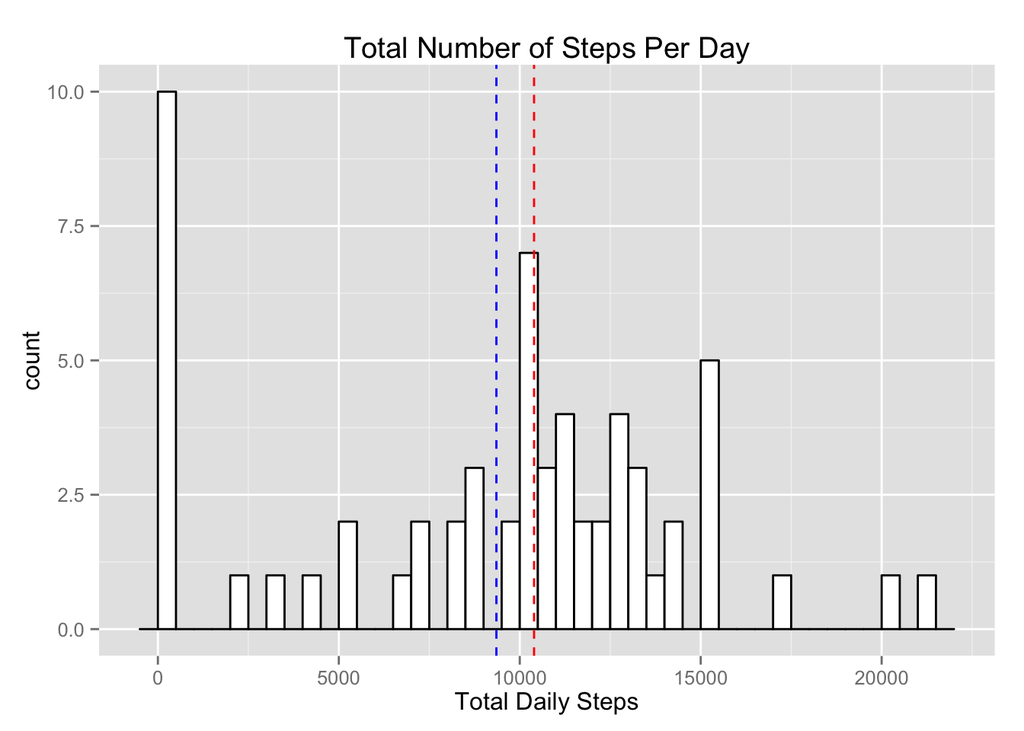

```r
ggplot(daily2, aes(x=dailysteps)) +
    geom_histogram(binwidth = 500, colour="black", fill="white") +
    labs(title="Total Number of Steps Per Day", x="Total Daily Steps") +
    geom_vline(aes(xintercept=mean(dailysteps)),
               color="blue", linetype="dashed") +
    geom_vline(aes(xintercept=median(dailysteps)),
               color="red", linetype="dashed")
```

2. Calculate and report the mean and median total number of steps taken per day

Mean Total Number of Steps Per Day

```r
sum(activity$steps,na.rm=T)/61
```

```
## [1] 9354
```

Median Number of Steps Per Day

```r
median(daily2$dailysteps)
```

```
## [1] 10395
```

## What is the average daily activity pattern?

A time series of the 5-minute interval (x-axis) and the average number of steps taken, averaged across all days (y-axis)

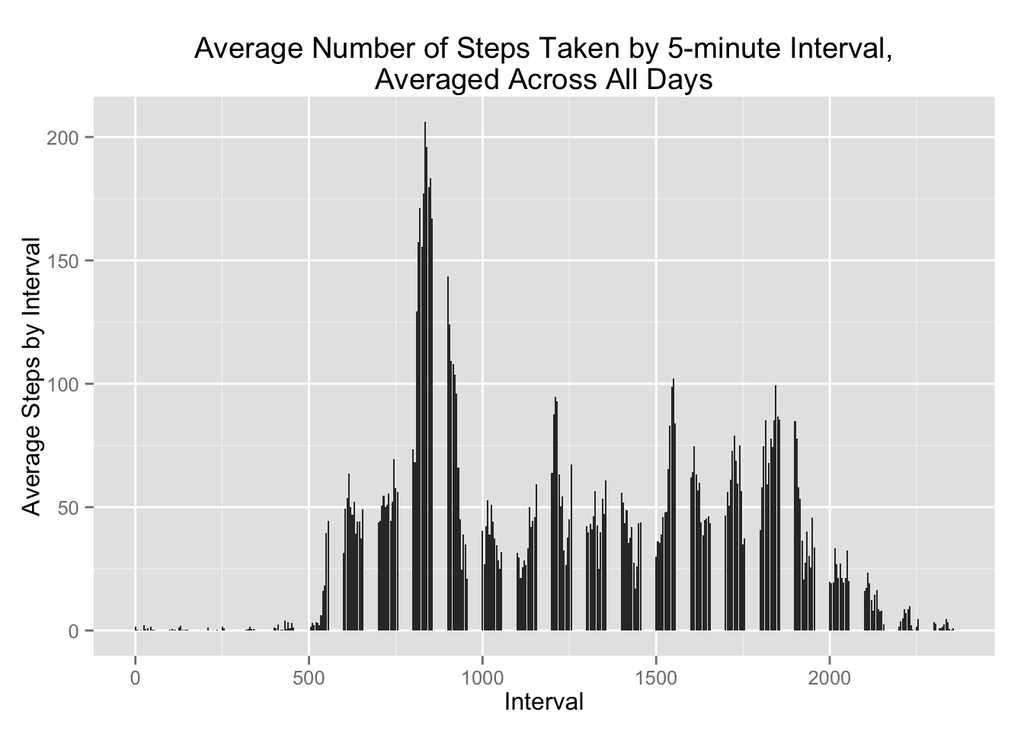

```r
int <- group_by(activity,interval)
int2 <- summarise(int,intavg = mean(steps,na.rm=TRUE))

ggplot(int2,aes(x=interval,y=intavg)) +
    geom_bar(stat="identity") +
    labs(title="Average Number of Steps Taken by 5-minute Interval,\nAveraged Across All Days", x="Interval",y="Average Steps by Interval")
```

Which 5-minute interval, on average across all the days in the dataset, contains the maximum number of steps?

```r
which.max(int2$intavg)
```

```
## [1] 165
```

```r
int2[165,]
```

```
## Source: local data frame [1 x 2]
##
##     interval intavg
## 165      835  206.2
```

## Imputing missing values

Calculate and report the total number of missing values in the dataset (i.e. the total number of rows with NAs)

```r
nrow(activity)-sum(complete.cases(activity))
```

```
## [1] 2304
```

Devise a strategy for filling in all of the missing values in the dataset.

```r
# Reorder int2 object, mean of each interval
df <- int2[order(int2$interval),]

# Replicate the mean of each interval 61 times for the 61 days in activity
df61 <- rep(df$intavg, times=61)

newsteps <- cbind(activity,df61) # Bind new column to original data set
newsteps$steps <- NULL
newsteps$intsteps <- newsteps$df61
newsteps$df61 <- NULL
newsteps$intsteps <- as.numeric(as.character(newsteps$intsteps))
head(newsteps)
```

```
##         date interval intsteps
## 1 2012-10-01        0  1.71698
## 2 2012-10-01        5  0.33962
## 3 2012-10-01       10  0.13208
## 4 2012-10-01       15  0.15094
## 5 2012-10-01       20  0.07547
## 6 2012-10-01       25  2.09434
```

Make a histogram of the total number of steps taken each day

Use dplyr to find total number of steps taken per day:

```r
new <- group_by(newsteps,date)
new2 <- summarise(new, newsteps = sum(intsteps, na.rm=T))
new2$newsteps <- as.numeric(as.character(new2$newsteps ))
```

A histogram of the total number of steps taken each day

```
## stat_bin: binwidth defaulted to range/30. Use 'binwidth = x' to adjust this.
```

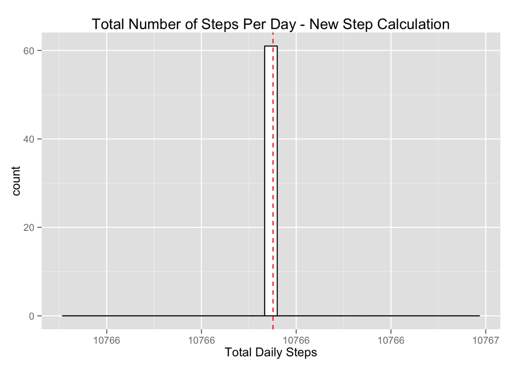

```r
ggplot(new2, aes(x=newsteps)) +
    geom_histogram(bindwidth=500, color="black", fill="white") +
    labs(title="Total Number of Steps Per Day - New Step Calculation",
         x="Total Daily Steps") +
    geom_vline(aes(xintercept=mean(newsteps)),
               color="blue", linetype="dashed") +
    geom_vline(aes(xintercept=median(newsteps)),
               color="red", linetype="dashed")
```

The new mean and median total number of steps taken per day

```r
# New Mean
sum(new2$newsteps,na.rm=T)/61
```

```
## [1] 10766
```

```r
# New Median
median(new2$newsteps)
```

```
## [1] 10766
```

Do these values differ from the estimates from the first part of the assignment?

```r
# Yes. The original mean for total number of steps taken per day is 9354.23. The new mean is 10766.19. The new median is also 10766.19. The old median was 10395.
```

What is the impact of imputing missing data on the estimates of the total daily number of steps?

```r
# About 1412 additional steps per day with the strategy I used to fill in the NAs.
```

## Are there differences in activity patterns between weekdays and weekends?

Create a new factor variable in the dataset with two levels – “weekday” and “weekend” indicating whether a given date is a weekday or weekend day.

```r
newsteps$day <- weekdays(as.Date(newsteps$date))
weekday <- newsteps[newsteps$day == "Monday" | newsteps$day == "Tuesday" | newsteps$day == "Wednesday" | newsteps$day == "Thursday" | newsteps$day == "Friday",]
weekend <- newsteps[newsteps$day == "Saturday" | newsteps$day == "Sunday",]
weekday$daytype <- rep("Weekday",times=nrow(weekday))
weekend$daytype <- rep("Weekend",times=nrow(weekend))
newsteps <- rbind(weekday,weekend)
```

Make a panel plot containing a time series plot (i.e. type = “l”) of the 5-minute interval (x-axis) and the average number of steps taken, averaged across all weekday days or weekend days (y-axis).

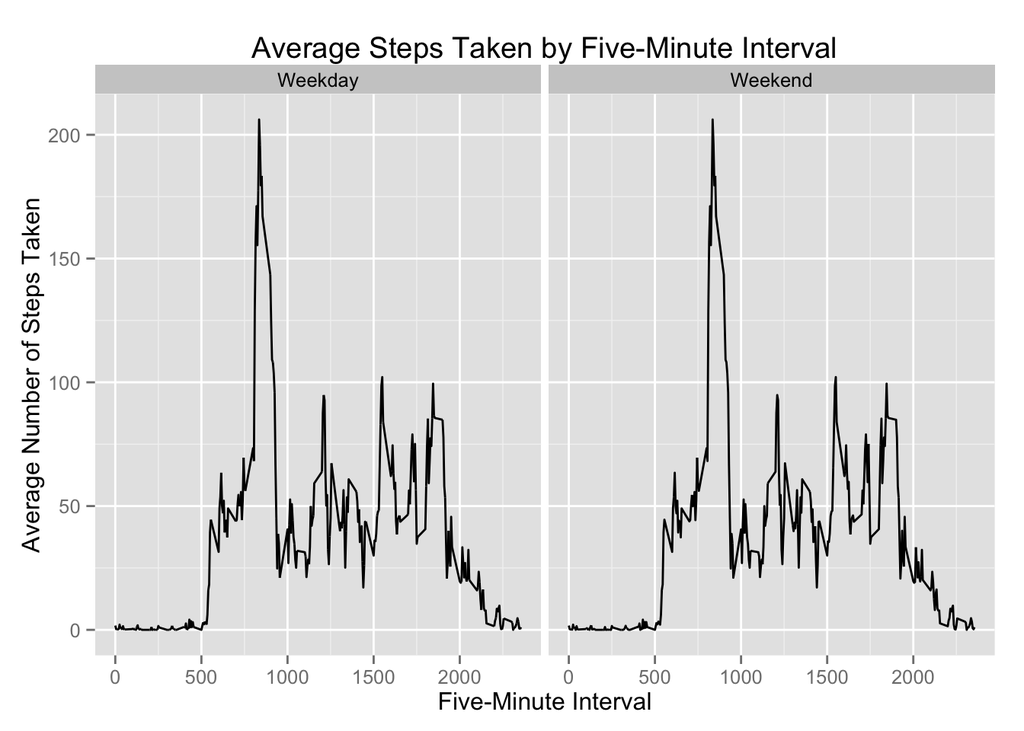

```r
ggplot(newsteps, aes(x=interval, y=intsteps)) +
    geom_line() +
    labs(x="Five-Minute Interval", y="Average Number of Steps Taken",
         title="Average Steps Taken by Five-Minute Interval") +
    facet_wrap( ~ daytype, ncol=2)
```

There aren’t any differences between weekdays and weekends given the strategy I used to fill in missing values.